# Lab Week 11 : Markov Chain Monte Carlo methods

STAT5003

Dr. Justin Wishart

Semester 2, 2022

### Preparation and assumed knowledge

- Viewed the Markov Chain Monte Carlo methods content in Module 11.

### Aims

- Implement Markov Chain Monte Carlo techniques to
  - Compute a posterior distribution
  - Generate samples from a non-trivial density

Exploring the Markov Chain Monte Carlo method. There isn’t any dataset in today’s tutorial, only simulated examples.

# 1 Compute chance of a coin flip

Estimate the P(Head) of a biased coin. In particular, estimate the posterior probability P(Head|Observed Data). Start by simulating some coin flips, where we know $p=$P(Head). Then, use MCMC to see if $p$ can be estimated from the data of the coin flips.

## 1.1 Simulate some data

Below is a way to simulate coin flips with chance of success $\theta = p = 0.7$ but you can use other simulated data if you wish. Denote these simulated values as the random variables $X_1, X_2, \ldots, X_n$ where $n = 200$

```r
set.seed(5003)
theta = 0.7 # P(Head)
N = 200
# simulate some coin flips
coin.flips <- rbinom(n = N, size = 1, prob = theta)
```

## 1.2 Determine how to compute the Likelihood of the parameter

Recall the Likelihood approach covered in a earlier module. In this case, each observation is assumed to be drawn from a Bernoulli (Binomial with $n = 1$) distribution. The formula is,

$$P(X = x|\theta) = \begin{cases} \theta^x(1 - \theta)^{(1 - x)}, &
\text{ if } x = 0 \text{ or }1;\\
0, & \text{otherwise}.\end{cases}$$

and it can be computed with `dbinom`. Write a function that computes the Likelihood of the parameter $\theta$ given all of the observed data.

$$L(\theta|X_1, X_2,\ldots, X_n) = \prod_{i = 1}^n P(X = x_i|\theta)$$

```r
likelihood <- function(theta, x)
  ...
```

## 1.3 Naive Metropolis Hastings

Write a Metropolis Hastings algorithm that takes a specified initial value for the parameter $\theta$ (or you can make it random if you wish) and then proposes a new value with a random walk sampler. For simplicity it is recommended to use the Gaussian density as the proposal density $q$. Psuedo-code of the Metropolis Hasting algorithm is given below. It needs some work that is obvious, other work required are the proposed theta needs to be between 0 and 1, it will need some code to ensure an impossible theta isn’t generated.

```r
# In this example, we set the prior of P(Head) to be a uniform distribution
niters <- 1000
curr.theta <- 0.5 # This is the parameter we want to find; initialise it

theta.chain <- numeric(niters) # Initialise the vector to be created
for(i in 0:(niters - 1)) {
  proposal.theta <- ... # A random draw from the proposal density that is conditioned on the previous iteration.

  curr.likeli <- ... # computed likelihood from the current theta
  proposal.likeli <- ... # computed likelihood from the proposed theta

  alpha <- min(..., 1)

   # Randomly decide whether to accept our new proposal
   if (runif(1) < alpha)
        curr.theta <- ...
   theta.chain[i + 1] <- ...
}
```

## 1.4 Log Likelihood computation

The log likelihood can be computed to stabilize the computation above where the computed likelihood values fall below the `.Machine$double.eps`, roughly speaking the smallest possible value that the computer can handle with precision. (see `? .Machine`).

Write a function that computes the log-Likelihood of the parameter $\theta$ given all of the observed data.

$$\mathcal{L}(\theta|X_1, X_2,\ldots, X_n) = \log L(\theta|X_1,
X_2,\ldots, X_n) = \log(\prod_{i = 1}^n P(X = x_i|\theta)) = \sum_{i =
1}^n \log P(X = x_i|\theta)$$

**Hint**: The argument of `log` is useful in the `dbinom` function. (See `? dbinom`).

```r
log.likelihood <- function(theta, x)
  ...
```

## 1.5 Log likelihood computed approach to the Metropolis-Hasting algorithm

Amend the Metropolis-Hastings algorithm above to use the log likelihood instead. Both the likelihood computations will now need to compute the log likelihood and the acceptance probability $\alpha$ will need to be modified.

```r
niters <- 1000
curr.theta <- 0.5 # This is the parameter we want to find; initialise it

theta.chain <- numeric(niters) # Initialise the vector to be created
for(i in 0:(niters - 1)) {
  proposal.theta <- ... # A random draw from the proposal density that is conditioned on the previous iteration.

  curr.log.likeli <- ... # computed log likelihood from the current theta
  proposal.log.likeli <- ... # computed log likelihood from the proposed theta

  alpha <- min(..., 1)  # This needs to be updated (hint, exp cancels out log)

   # Randomly decide whether to accept our new proposal
   if (runif(1) < alpha)
        curr.theta <- ...
   theta.chain[i + 1]
}
```

# 2 Generate Samples from a non-trivial distribution

Use the MCMC procedure to generate random samples from the following probability distribution function. This function is simply the sum of two normal distributions. Explore the use of the proposal distribution to explore the target space in the MCMC algorithm.

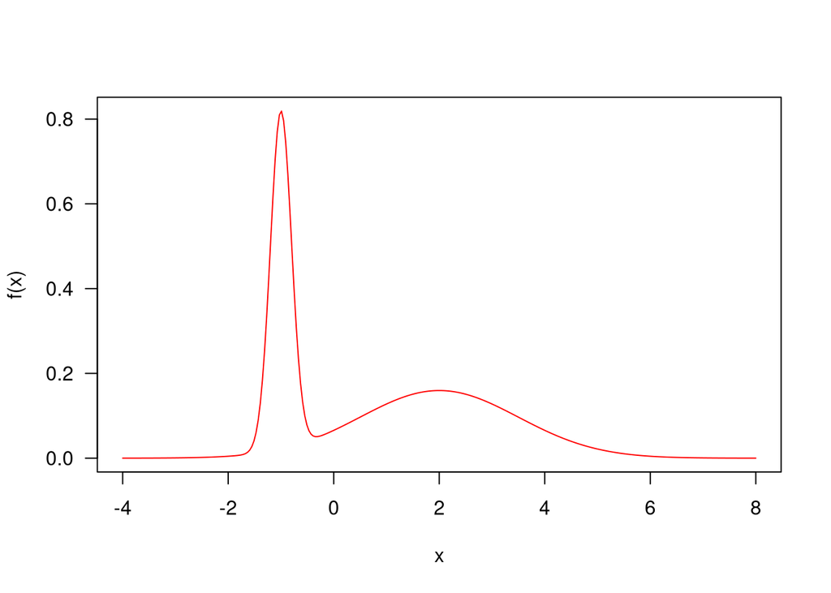

```r
p <- 0.4
mn <- c(-1, 2)
std <- c(0.2, 1.5)
f <- function(x, mu = mn, sd = std)  p * dnorm(x, mu[1], sd[1]) + (1 - p) * dnorm(x, mu[2], sd[2])

curve(f(x), col = "red", from = -4, to = 8, n = 300, las = 1)
```

## 2.1 Use Metropolis-Hastings algorithm to draw samples from the normal mixture above

Use the Gaussian density centered on the current point as the proposal transition. Consider the random walk Metropolis-Hastings algorithm again (symmetric proposal distribution). Define a function $q$ in `R` to be a sample from a Gaussian distribution but with two parameters, $x$ to denote the current value of the markov chain and $\sigma$ to be the sd of the Gaussian distribution.

```r
q <- function(x, sigma) ...(1, mean = ..., sd = ...)
```

## 2.2 Function to do a random walk Metropolis-Hasting algorithm

Write a function that uses a random walk Metropolis-Hastings sampling of the target distribution `f` that uses your proposal function `q` but has argument, `sigma` to control the sd parameter of the proposal distribution. i.e. your function should have signature.

```
#' x_0 : Initial value of the Markov chain
#' n : number of iterations to compute
#' sigma : size of the sd in the proposal distribution
function(x_0, n, sigma)
```

```r
mc.algorithm <- function(x_0, n, sigma)
{
    ...
}
```

## 2.3 Explore the impact of choices of `x_0` and `sigma`

Sample the target distribution using the random walk Metropolis-Hastings sampling with different choices of `x_0` and `sigma` and view and interpret the output. Consider how the different choices of the starting point `x_0` and the ability for the proposal to explore the space with different values of `sigma` impact the results of the algorithm. You can choose your own different parameters or use these ones provided `x_0.vals <- c(-1, 1, 5)` and `sigma.vals <- c(0.01, 0.5, 20)`. To visualize your results, consider plotting the probability histogram of the outputs and drawing the true target density on top.

**Hint**: `expand.grid` might be a useful function to look at many combinations of choices of `x_0` and `sigma`